# Data Modeling of Global Depression Prevalence Data

MathisWo

2025-08-03

# 🧹 1. Load and Clean the Raw Dataset

Data Source: Global Burden of Disease Collaborative Network. Global Burden of Disease Study 2021 (GBD 2021) Results. Seattle, United States: Institute for Health Metrics and Evaluation (IHME), 2022. Available from https://vizhub.healthdata.org/gbd-results/.

Load and clean the original depression prevalence dataset.

```r
# Load CSV
data_raw <- read_csv("IHME-GBD_2021_DATA-dd81f9d8-1.csv")

# renaming variables, filtering for percent prevalence, selecting relevant variables
data_clean <- data_raw %>%
  rename(
    country_id = location_id,
    country = location_name,
    sex = sex_name,
    age = age_name,
    metric = metric_name,
    prevalence = val
  ) %>%
  filter(metric == "Prozent") %>%
  select(country_id, country, year, sex, age, prevalence) %>%
  arrange(country)
```

# 🌍 2. Create Dimension Tables

## 2.1 Country Dimension Table

```r
# creating dimension table for country, sorted alphabetically
country_dim <- data_clean %>%
  distinct(country) %>%
  arrange(country) %>%
  mutate(country_id = row_number()) %>%
  relocate(country_id)

write_csv(country_dim, "country_dim.csv") # writing .csv file for country dimension table
```

## 2.2 Year Dimension Table

```r
# creating dimension table for year
year_dim <- data_clean %>%
  distinct(year) %>%
  arrange(year) %>%
  mutate(year_id = row_number()) %>%
  relocate(year_id)

write_csv(year_dim, "year_dim.csv") # writing .csv file for year dimension table
```

# 📊 3. Create Fact Table

Join the cleaned dataset with the dimension tables to create a structured fact table.

```r
# creating fact table for prevalence data
df_fact <- data_clean %>%
  select(-country_id) %>%  # dropping old country_id
  left_join(country_dim, by = "country") %>%
  left_join(year_dim, by = "year") %>%
  mutate(prevalence_id = row_number()) %>% # creating new id for primary key in fact table
  relocate(prevalence_id) %>%
  select(-sex, -age, -country, -year) # dropping redundant or irrelevant variables

write_csv(df_fact, "df_fact.csv") # writing .csv file for fact table
```

# 🐘 4. SQL Table Setup in PostgreSQL (via pgAdmin)

Create tables in PostgreSQL with appropriate primary and foreign keys.

**Run this code in pgAdmin:**

```sql
-- Country Dimension Table
CREATE TABLE country_dim (
    country_id INT PRIMARY KEY,
    country TEXT UNIQUE NOT NULL
);


-- Year Dimension Table
CREATE TABLE year_dim (
    year_id INT PRIMARY KEY,
    year INT UNIQUE NOT NULL
);


-- Fact Table
CREATE TABLE depression_fact (
  prevalence_id SERIAL PRIMARY KEY,
  prevalence NUMERIC,
    country_id INT REFERENCES country_dim(country_id),
    year_id INT REFERENCES year_dim(year_id)
);
```

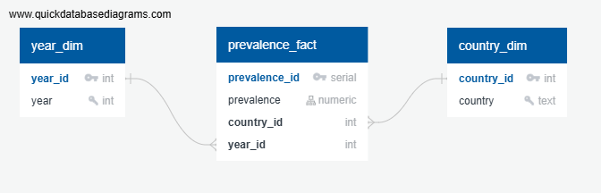

Database Diagram

# 📥 5. Import Data to PostgreSQL via pgAdmin interface

# ✅ Summary

- Loaded and cleaned real-world mental health data
- Structured SQL database using a dimensional model (star schema)
- Star schema can be extended, e.g. by adding a region/continent dimension table in addition to the country dimension table or by creating dimension tables for sex and age groups (if data is available)
- Imported data into PostgreSQL for analysis
- Foundation for further visualizations or SQL analytics